# R Notebook

We'll look at the cell ontology.

General purpose ontology manipulation in R can be done with ontologyX tools (ontologyIndex, ontologyPlot, ontologySimilarity?) and ontoProc offers bio-geared ontology functionality.

```r
library(ontoProc)
library(ontologyIndex)
library(ontologyPlot)
```

General ontologies are often stored in .owl format and, in terms of technologies, ontologies can be served by graph databases. OBO, the open biological ontologies foundation, offers bio-related ontologies in .OBO format: http://www.obofoundry.org/ontology/cl.html

getCellOnto() can be used to extract ontology and represent it as orthology_index class as defined by the orthologyIndex package. orthologyIndex is a package for general-purpose low-level ontology manipulation.

Let's explore oncoProc functionality

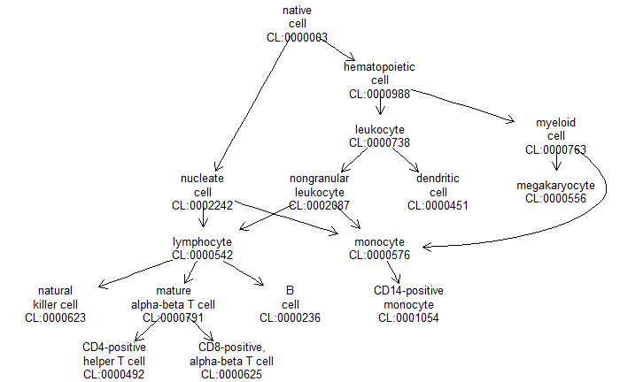

```r
cl = getCellOnto()
# Plot CL for terms
cell_v = c("CL:0000492", "CL:0001054", "CL:0000236", "CL:0000625",
   "CL:0000576", "CL:0000623", "CL:0000451", "CL:0000556")
onto_plot2(cl, cell_v)
```

```r
# feats = CLfeats(cl, "CL:0000492")
# Names from cell line ontology
# cleannames = cleanCLOnames()
# Start app and dataframes with cell types properties
# ctmarks(cl)
# onto_roots(cl)
recognizedPredicates()
```

```
                           hasPMP                          lacksPMP                           hiPMAmt
       "has_plasma_membrane_part"      "lacks_plasma_membrane_part" "has_high_plasma_membrane_amount"
                          loPMAmt                           hasPart                         lacksPart
 "has_low_plasma_membrane_amount"                        "has_part"                      "lacks_part"
                           hasExp                          lacksExp
              "has_expression_of"             "lacks_expression_of"
```

Explore ontologyIndex functionality

```r
cl = getCellOnto()  # already ontology_index class
# Explore the data structure
str(cl, max.level=1)
```

```
List of 6
 $ id       : Named chr [1:6546] "CL:0000000" "CL:0000001" "CL:0000002" "CL:0000003" ...
  ..- attr(*, "names")= chr [1:6546] "CL:0000000" "CL:0000001" "CL:0000002" "CL:0000003" ...
 $ name     : Named chr [1:6546] "cell" "primary cultured cell" "obsolete immortal cell line cell" "native cell" ...
  ..- attr(*, "names")= chr [1:6546] "CL:0000000" "CL:0000001" "CL:0000002" "CL:0000003" ...
 $ parents  :List of 6546
 $ children :List of 6546
 $ ancestors:List of 6546
 $ obsolete : Named logi [1:6546] FALSE FALSE FALSE FALSE FALSE FALSE ...
  ..- attr(*, "names")= chr [1:6546] "CL:0000000" "CL:0000001" "CL:0000002" "CL:0000003" ...
 - attr(*, "class")= chr "ontology_index"
 - attr(*, "version")= chr [1:13] "date: 13:09:2017 23:16" "auto-generated-by: pronto v0.8.0" "import: http://purl.obolibrary.org/obo/cl/imports/ro_import.owl" "import: http://purl.obolibrary.org/obo/cl/imports/ncbitaxon_import.owl" ...
```

```r
term = "CL:0000492"
cl$name[term]
```

```
                  CL:0000492
"CD4-positive helper T cell"
```

```r
cl$parents[term]
```

```
$`CL:0000492`
[1] "CL:0000624" "CL:0000912"
```

```r
cl$name[cl$ancestors[[term]]]
```

```
                      BFO:0000002                       BFO:0000004                       BFO:0000040
                     "continuant"          "independent continuant"                 "material entity"
                     CARO:0000006                      CARO:0000003                        CL:0000000
     "material anatomical entity"            "anatomical structure"                            "cell"
                       GO:0005575                        GO:0005623                        CL:0000003
             "cellular_component"                            "cell"                     "native cell"
                       CL:0000219                        CL:0000255                        CL:0000548
                    "motile cell"                 "eukaryotic cell"                     "animal cell"
                       CL:0002371                        CL:0000988                        CL:0000738
                   "somatic cell"              "hematopoietic cell"                       "leukocyte"
                       CL:0002087                        CL:0002242                        CL:0000542
          "nongranular leukocyte"                   "nucleate cell"                      "lymphocyte"
                       CL:0000084                        CL:0000789                        CL:0002419
                         "T cell"               "alpha-beta T cell"                   "mature T cell"
                       CL:0000791                        CL:0000624                        CL:0000911
       "mature alpha-beta T cell" "CD4-positive, alpha-beta T cell"                 "effector T cell"
                       CL:0000912                        CL:0000492
                  "helper T cell"      "CD4-positive helper T cell"
```

```r
# Get term properties
get_term_property(
    ontology=cl,
    property="ancestors",
    term="CL:0000492",
    as_names=TRUE
)
```

```
                      BFO:0000002                       BFO:0000004                       BFO:0000040
                     "continuant"          "independent continuant"                 "material entity"
                     CARO:0000006                      CARO:0000003                        CL:0000000
     "material anatomical entity"            "anatomical structure"                            "cell"
                       GO:0005575                        GO:0005623                        CL:0000003
             "cellular_component"                            "cell"                     "native cell"
                       CL:0000219                        CL:0000255                        CL:0000548
                    "motile cell"                 "eukaryotic cell"                     "animal cell"
                       CL:0002371                        CL:0000988                        CL:0000738
                   "somatic cell"              "hematopoietic cell"                       "leukocyte"
                       CL:0002087                        CL:0002242                        CL:0000542
          "nongranular leukocyte"                   "nucleate cell"                      "lymphocyte"
                       CL:0000084                        CL:0000789                        CL:0002419
                         "T cell"               "alpha-beta T cell"                   "mature T cell"
                       CL:0000791                        CL:0000624                        CL:0000911
       "mature alpha-beta T cell" "CD4-positive, alpha-beta T cell"                 "effector T cell"
                       CL:0000912                        CL:0000492
                  "helper T cell"      "CD4-positive helper T cell"
```

```r
# Remove redundant terms from a set of terms
terms = c("CL:0000492", "CL:0001054", "CL:0000236", "CL:0000625",
   "CL:0000576", "CL:0000623")
minimal = minimal_set(cl, terms)
# Find all ancestors of a set of terms
ancestors_ids = get_ancestors(cl, terms)
cl$name[ancestors_ids]
```

```
                      BFO:0000002                       BFO:0000004                       BFO:0000040
                     "continuant"          "independent continuant"                 "material entity"
                     CARO:0000006                      CARO:0000003                        CL:0000000
     "material anatomical entity"            "anatomical structure"                            "cell"
                       GO:0005575                        GO:0005623                        CL:0000003
             "cellular_component"                            "cell"                     "native cell"
                       CL:0000219                        CL:0000255                        CL:0000548
                    "motile cell"                 "eukaryotic cell"                     "animal cell"
                       CL:0002371                        CL:0000988                        CL:0000738
                   "somatic cell"              "hematopoietic cell"                       "leukocyte"
                       CL:0002087                        CL:0002242                        CL:0000542
          "nongranular leukocyte"                   "nucleate cell"                      "lymphocyte"
                       CL:0000084                        CL:0000789                        CL:0002419
                         "T cell"               "alpha-beta T cell"                   "mature T cell"
                       CL:0000791                        CL:0000624                        CL:0000911
       "mature alpha-beta T cell" "CD4-positive, alpha-beta T cell"                 "effector T cell"
                       CL:0000912                        CL:0000492                        CL:0000763
                  "helper T cell"      "CD4-positive helper T cell"                    "myeloid cell"
                       CL:0000766                        CL:0000226                        CL:0000842
              "myeloid leukocyte"            "single nucleate cell"                "mononuclear cell"
                       CL:0011115                        CL:0000576                        CL:0001054
                 "precursor cell"                        "monocyte"          "CD14-positive monocyte"
                       CL:0000945                        CL:0000236                        CL:0000625
        "lymphocyte of B lineage"                          "B cell" "CD8-positive, alpha-beta T cell"
                       CL:0001065                        CL:0001067                        CL:0000623
           "innate lymphoid cell"    "group 1 innate lymphoid cell"             "natural killer cell"
```

```r
# Operations on subclasses
# intersection_with_descendants()
# exclude_descendants()
# prune_descendants()
properties = names(cl)
# cl$has_high_plasma_membrane_amount
```

Let's use the tools to explore some cell ontologies. We can see that 'bladder cell' is a term identifying all types of cells identified in the bladder.

```r
# Let's look into the bladder cells
bladder_ids = c('CL:1001319','CL:1001428','CL:0000738')
cl$name[bladder_ids]
```

```
               CL:1001319                CL:1001428                CL:0000738
           "bladder cell" "bladder urothelial cell"               "leukocyte"
```

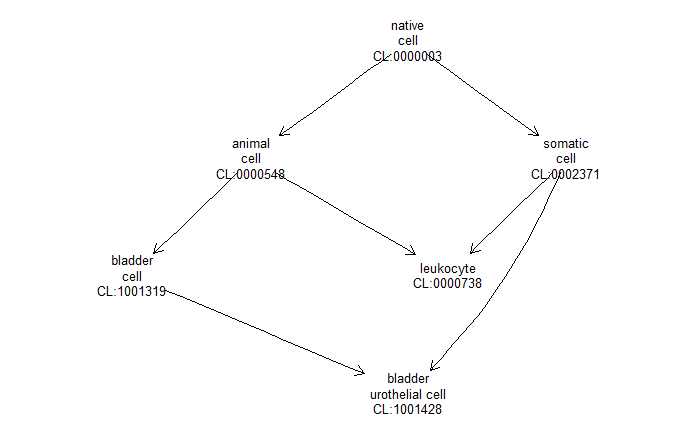

```r
onto_plot2(cl, bladder_ids)
```

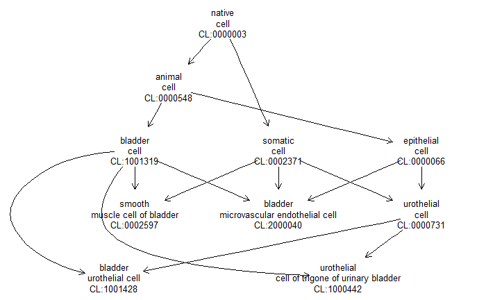

```r
# Let's look into all descendants of the bladder cell
bladder_descendants = get_descendants(cl, 'CL:1001319')
onto_plot2(cl, bladder_descendants)
```

[figure not shown]

```r
macrophage_descendants = get_descendants(cl, cl$id[cl$name == 'macrophage'])
onto_plot2(cl, macrophage_descendants)
```

```r
# Cellname mapping to cell ontology ----
# Let's explore the brain's cell types
brain_celltypes_names = c(
    'Bergmann glial cell',
    'CD8-positive, alpha-beta T cell',
    'T cell',
    'astrocyte',
    'brain pericyte',
    'endothelial cell',
    'ependymal cell',
    'interneuron',
    'macrophage',
    'mature NK T cell',
    'medium spiny neuron',
    'microglial cell',
    'neuroepithelial cell',
    'neuron',
    'neuronal stem cell',
    'oligodendrocyte',
    'oligodendrocyte precursor cell'
)
cellnames = cl$name
library(purrr)
map_lgl(
    brain_celltypes_names,
    ~ map_cellname(.x, cellnames)
)
```

```
 [1]  TRUE  TRUE  TRUE  TRUE  TRUE  TRUE  TRUE  TRUE  TRUE  TRUE  TRUE  TRUE FALSE  TRUE  TRUE  TRUE  TRUE
```

```r
map_cellname(brain_celltypes_names[6], cellnames)
```

```
[1] TRUE
```

```r
map_cellname = function (name, cellnames){
    idxs = grep(
        pattern=name,
        x=cellnames,
        ignore.case=TRUE
    )
    return(length(idxs)>0)
}
```

We can use cell ontology and the above functionality to help annotate cell types in a couple of ways: - for each cell ontology id, get the path to root for manual inspection - for each cell ontology id, get the properties - for each tissue, get the minimal set of terms. Use these to evaluate how much the given tissue covers the space of cell types (e.g. width of the ontology subgraph obtained by subsetting the general ontology by the terms in the minimal set). - for each tissue, plot the relevant subgraph and the non-redundant, i.e. minimal, subgraph.

```r
celltype_names = brain_celltypes_names
ontology = cl
search_ontology_cellnames = function(ontology, cellnames) {

    ontology_cellnames = ontology$name

    search_cellname = function(cellnames_to_search, cellname_to_search) {
        idxs = grep(
            pattern=cellname_to_search,
            x=cellnames_to_search,
            ignore.case=TRUE
        )
        is_identified = length(idxs) > 0
        return(is_identified)
    }

    identified_mask = map_lgl(
        cellnames,
        ~ search_cellname(ontology_cellnames, .x)
    )
    unidentified_mask = !identified_mask

    message(paste0("search_ontology_cellnames: ",
                   sum(unidentified_mask),
                   ' cell names not found in ontology')
    )

    return(cellnames[unidentified_mask])
}
```

```r
id = "CL:0000492"  # a cell ontology id
# cell ontology unique ids corresponding to cell types from brain
ids = c("CL:0000644", "CL:0000127", "CL:0000128",
        "CL:2000043", "CL:0000115", "CL:0000540",
        "CL:0002453")
cl = getCellOnto()  # cell ontology
get_path_to_root = function(ontology=cl,
                            id) {
    stop('Not implemented')
}
get_properties = function(ontology=cl,
                          id) {
    stop('Not implemented')
}
compute_minimal_set = function(ontology=cl,
                               ids) {
    stop('Not implemented')
}
plot_ontology_subset = function(ontology=cl,
                                ids) {
    stop('Not implemented')
}
```

In the TMS paper, they do graph-based clustering on PCA-reduced representation of raw data. They then map cell types to : if 1-1 ok, else flag for manual/expert annotation by the tissue expert. That explains the inconsistency between cell ontology and final cell labels.

A solution could be to use the current version of cell ontology. Since some time has passed, it may be the case that the new cell types have been resolved in CL. Maybe they're collaborating with CL to resolve. We should flag ourselves the cell types that can't be resolved by current CL and discuss with the TMS / CL team.